# Star Wars Episode III Script Analysis

Justin Farnsworth

August 26, 2020

# Summary

On May 19, 2005, *Star Wars: Episode III - Revenge of the Sith*, the third and final installation of the Star Wars Prequel Trilogy, was released. The movie told the story about a young, but powerful Jedi knight that succumbed to dark side out of fear of his wife dying. It also showed the extermination of the Jedi as well as the fall of the Galactic Republic, which would be replaced by the Galactic Empire, with a Sith lord at the helm. The movie helps transition the saga into the Original Trilogy.

NOTE: The analysis was done on the script of the movie, not the movie itself. The dialogue may be different in the movie than in the script.

This script can be accessed here: https://www.imsdb.com/scripts/Star-Wars-Revenge-of-the-Sith.html

For this project, the following packages were used.

```r
# Required packages
if (!require(tidyverse)) { install.packages("tidyverse"); library(tidyverse) }
if (!require(tidytext)) { install.packages("tidytext"); library(tidytext) }
if (!require(R.utils)) { install.packages("R.utils"); library(R.utils) }
if (!require(rvest)) { install.packages("rvest"); library(rvest) }
```

# Loading The Data

The page didn’t provide a downloadable file of the script. To obtain the script, we extracted the script via web scraping.

The following code was used to extract the script from the HTML page:

```r
# Download the script
# Source: Internet Movie Screenplay Database
url <- "https://www.imsdb.com/scripts/Star-Wars-Revenge-of-the-Sith.html"
html_page <- read_html(url) %>% html_nodes("table")

# Extract the script from the page
script <- html_page[13] %>% html_text

# Remove the HTML page variable
rm(html_page)
```

# Cleaning The Data

Since we’re interested in the dialogue, we omitted everything but the dialogue. The lines could be mostly filtered by checking for the colon followed by a space. The remaining text had to be removed directly.

Regarding the names of the characters, we noticed a lot of inconsistencies. Some of the character’s names were misspelled and aliases were present. To ensure the names are uniform, the names were corrected and aliases were changed to the character’s original name. For example, Darth Vader was changed to Anakin since this refers to the same person.

The lines were the easiest to clean up as we removed any parantheses along with the text inside them. We also have to fix several character symbols that were converted to their hexadecimal representation when loading the HTML page.

```r
# Convert the script into a data frame
script <- unlist(str_split(script, "\\n|\\r|\\t")) %>%
  as_tibble() %>%
  rename(Line = value)

# Keep only the dialogue and split the name and quotes into separate columns
script <- script %>%
  filter(!str_detect(Line, "^$")) %>%
  filter(!str_detect(Line, "STAR WARS EPISODE 3: REVENGE OF THE SITH SCRIPT")) %>%
  filter(!str_detect(Line, "Star Wars: Revenge of the Sith")) %>%
  filter(str_detect(Line, ": "))  %>%
  separate(Line, into = c("Character", "Line"), sep = ": ", extra = "merge")

# Clean up the character names in the script
# Note: Aliases have been changed to the character's actual name
script <- script %>%
  mutate(Character = str_replace(Character, "ANAKINN|DARTH VADER", "ANAKIN")) %>%
  mutate(Character = str_replace(Character, "^BAIL$", "BAIL ORGANA")) %>%
  mutate(Character = str_replace(Character, "^CLONE PILOT$", "CLONE PILOT 1")) %>%
  mutate(Character = str_replace(Character, "^DA[BR]TH S[Il]DIOUS", "PALPATINE")) %>%
  mutate(Character = str_replace(Character, "FANGZAR", "FANG ZAR")) %>%
  mutate(Character = str_replace(Character, "FlRESHIP PILOT", "FIRESHIP PILOT")) %>%
  mutate(Character = str_replace(Character, "^G-3PO$|^THREEPIO$", "C-3PO")) %>%
  mutate(Character = str_replace(Character, "G[il]DDEAN DANU", "GIDDEAN DANU")) %>%
  mutate(Character = str_replace(Character, "^Kl-ADI-MUNDI$", "KI-ADI-MUNDI")) %>%
  mutate(Character = str_replace(Character, "^MACE$|^MACE W[il]NDU$", "MACE WINDU")) %>%
  mutate(Character = str_replace(Character, "^OBI-WAN $", "OBI-WAN")) %>%
  mutate(Character = str_replace(Character, "QUI ?-GON", "QUI-GON")) %>%
  mutate(Character = str_replace(Character, "SUPER BATTLE DROID 2", "SUPER BATTLE DROID 3")) %>%
  mutate(Character = str_replace(Character, "SUPER BATTLE DROID 1", "SUPER BATTLE DROID 2")) %>%
  mutate(Character = str_replace(Character, "^SUPER BATTLE DROID$", "SUPER BATTLE DROID 1")) %>%
  mutate(Character = str_replace(Character, "TlON MEDON", "TION MEDON")) %>%
  filter(!str_detect(Character, "^PALPATINE ")) %>%
  separate_rows(Character, sep = "/")

# Clean up the lines and remove any parantheses along with text inside them
script <- script %>%
  mutate(Line = str_replace_all(Line, " ?\\([^\\(\\)]*\\) ?", " ")) %>%
  mutate(Line = str_replace_all(Line, "\u0085", "…")) %>%
  mutate(Line = str_trim(str_replace_all(Line, "\u0092", "'")))
```

After cleaning up the script, we have the following table:

| Character | Line |
| --- | --- |
| ANAKIN | There isn’t a droid made that can out fly you, Master, and no other way to get to the Chancellor . . . |
| OBI-WAN | Look out, four droids inbound . . . |
| OBI-WAN | We’ve got to split them up. |
| ANAKIN | Break left, fly through the guns on that tower. |
| OBI-WAN | Easy for you to say . . . why am I always the bait? |
| ANAKIN | Don’t worry. I’m coming around behind you. |
| OBI-WAN | Anakin, they’re all over me! |
| ANAKIN | Dead ahead! Closing . . . lock onto him, Artoo . . . |
| ANAKIN | We got him, Artoo! |
| ANAKIN | I copy, Artoo. |
| OBI-WAN | I’m going down on the deck. |
| ANAKIN | Good idea … I need some room to maneuver. |
| ANAKIN | Cut right. Do you hear me?! Cut right. Don’t let him get a handle on you. Come on, Artoo, lock on! Lock on! |
| OBI-WAN | Hurry up! I don’t like this! |
| OBI-WAN | Ouch! |
| OBI-WAN | Don’t even try to fix it, Arfour. I’ve shut it down. |
| ANAKIN | We’re locked on … we’ve got him . . . |
| ANAKIN | Yeah! We got him . . . good going, Artoo. |
| OBI-WAN | Next time you’re the bait . . . Now let’s find the Command Ship and get on with it … |
| ANAKIN | Lock onto them, Artoo. Master, General Grievous’s ship is directly ahead. |
| ANAKIN | The one crawling with vulture droids. |
| OBI-WAN | I see it. Oh, this is going to be easy. |
| ANAKIN | Come on, Master. |
| OBI-WAN | Not this time. There’s too much at stake. We need help. Odd Ball, do you copy? |
| ODD BALL | Copy, Red Leader. |
| OBI-WAN | Mark my position and form your squad up behind me . . . |
| ODD BALL | We’re on your tail, General Kenobi. Set S-foils in attack position. |
| ANAKIN | This is where the fun begins. Ten Vulture Droids straight ahead, coming down the left side. |
| OBI-WAN | Add five Tri-fighters on the right . . . |
| ANAKIN | I’m going head to head. See you. |

[output cut: 1124 more lines]

We can also identify who had the most lines. We see that Anakin had the most lines followed by Obi-Wan, Padme, and Palpatine. This makes sense as they are the main characters in the movie.

| Character | Total |
| --- | --- |
| ANAKIN | 320 |
| OBI-WAN | 242 |
| PADME | 131 |
| PALPATINE | 131 |
| YODA | 61 |
| BAIL ORGANA | 40 |
| MACE WINDU | 39 |
| GENERAL GRIEVOUS | 27 |
| C-3PO | 26 |
| CLONE COMMANDER CODY | 10 |
| PILOT | 8 |
| KI-ADI-MUNDI | 7 |
| MEDICAL DROID | 6 |
| MON MOTHMA | 6 |
| TION MEDON | 6 |
| CLONE SERGEANT | 5 |
| COUNT DOOKU | 5 |
| CLONE COMMANDER GREE | 4 |
| MAS AMEDDA | 4 |
| NUTE GUNRAY | 4 |
| ODD BALL | 4 |
| SUPER BATTLE DROID 2 | 4 |
| CAPTAIN TYPHO | 3 |
| CLONE CAPTAIN | 3 |
| CLONE TROOPER | 3 |
| CREATURE | 3 |
| FANG ZAR | 3 |
| GIDDEAN DANU | 3 |
| GUARD | 3 |
| QUI-GON | 3 |
| WRANGLER | 3 |
| AAYLA | 2 |
| BANA BREEMU | 2 |
| BODYGUARD | 2 |
| CAPTAIN ANTILLES | 2 |
| CLONE COMMANDER BACARA | 2 |
| CLONE COMMANDER THIRE | 2 |
| JAR JAR | 2 |
| SUPER BATTLE DROID G21 | 2 |
| AT-ST CLONE SERGEANT | 1 |
| BATTLE DROID | 1 |
| BLY | 1 |
| BODYGUARD I | 1 |
| CAPTAIN | 1 |
| CHI EEKWAY | 1 |
| CLONE COMMANDER APPO | 1 |
| CLONE PILOT 1 | 1 |
| CLONE PILOT 2 | 1 |
| DROID 1 | 1 |
| DROID 2 | 1 |
| FIRESHIP PILOT | 1 |
| MOTEE | 1 |
| PLO KOON | 1 |
| ROYAL GUARD | 1 |
| RUNE HAAKO | 1 |
| SUPER BATTLE DROID 1 | 1 |
| SUPER BATTLE DROID 3 | 1 |
| SUPER BATTLE DROID R77 | 1 |
| TERR TANEEL | 1 |
| YOUNGLINGS | 1 |

# Sentiment Analysis - Bing

We first analyzed the data using the Bing sentiments, which allowed for a simple sentiment analysis by categorizing the tokens as either positive or negative. Not all words received a sentiment, however, as some words are not present in the Bing sentiments.

It is also important to note that stop words were removed since they provide minimal to no value for the analysis.

After tokenizing and adding the sentiments to the words in the script, we observed the most common word was `jedi`.

| Word | Total |
| --- | --- |
| jedi | 114 |
| anakin | 104 |
| master | 77 |
| chancellor | 60 |
| council | 52 |
| artoo | 42 |
| time | 36 |
| force | 33 |
| senate | 33 |
| lord | 31 |
| republic | 31 |
| power | 30 |
| sith | 29 |
| dark | 27 |
| kenobi | 26 |
| obi-wan | 25 |
| sir | 24 |
| war | 24 |
| grievous | 23 |
| padme | 23 |
| stop | 20 |
| droids | 19 |
| ship | 19 |
| move | 18 |
| senator | 18 |
| count | 15 |
| hold | 15 |
| kill | 15 |
| save | 15 |
| sense | 15 |

Out of the positive words, the most common word was `master`, which was more prevalent than the next 6 positive words combined!

| Word | Total |
| --- | --- |
| master | 77 |
| love | 14 |
| powerful | 14 |
| trust | 13 |
| safe | 12 |
| steady | 10 |
| strong | 9 |
| easy | 8 |
| patience | 6 |
| peace | 6 |
| assure | 5 |
| wise | 5 |
| fine | 4 |
| happy | 4 |
| promise | 4 |
| defeated | 3 |
| faith | 3 |
| pride | 3 |
| protect | 3 |
| proud | 3 |

Out of the negative words, the most common word was `dark`.

| Word | Total |
| --- | --- |
| dark | 27 |
| grievous | 23 |
| kill | 15 |
| destroy | 13 |
| fear | 12 |
| killed | 11 |
| lost | 10 |
| death | 9 |
| attack | 8 |
| dangerous | 8 |
| worry | 8 |
| wrong | 8 |
| bad | 7 |
| break | 7 |
| afraid | 6 |
| dead | 6 |
| die | 6 |
| lose | 6 |
| plot | 6 |
| anger | 5 |

Despite `master` being the most prevalent word out of all the words with sentiments, there were significantly more negative words than positive words.

| Sentiment | Total |
| --- | --- |
| Positive | 327 |
| Negative | 478 |

The following graph is a visual representation of total number of positive and negative sentiments.

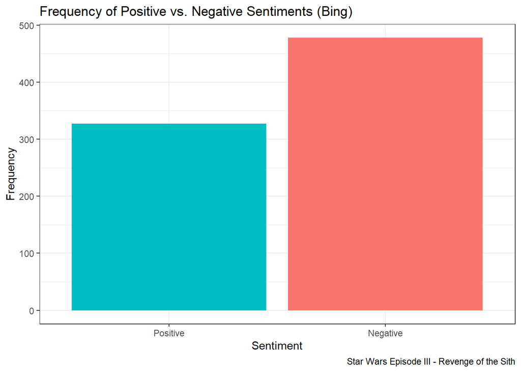

For a movie that was about the downfall of the Galactic Republic, the manipulation of a powerful Jedi knight who feared the death of his wife, the extermination of the Jedi, and the rise of the Galactic Empire that is ruled by a ruthless Sith lord, it made sense that there would be more negative sentiments than positive sentiments. However, we wanted to reveal who was the most positive and who was the most negative.

For each character, the spread was calculated by subtracting the number of negative sentiments from the number of positive sentiments. Since some characters didn’t have either positive or negative sentiments, the missing values were filled with 0.

| Character | Negative | Positive | NA | Spread |
| --- | --- | --- | --- | --- |
| NUTE GUNRAY | 1 | 5 | 16 | 4 |
| ANAKIN | 107 | 110 | 610 | 3 |
| AAYLA | 0 | 2 | 2 | 2 |
| QUI-GON | 2 | 4 | 21 | 2 |
| CHI EEKWAY | 0 | 1 | 1 | 1 |
| CREATURE | 0 | 1 | 4 | 1 |
| MAS AMEDDA | 1 | 2 | 10 | 1 |
| SUPER BATTLE DROID G21 | 0 | 1 | 5 | 1 |
| YOUNGLINGS | 0 | 1 | 1 | 1 |
| BAIL ORGANA | 8 | 8 | 116 | 0 |
| BATTLE DROID | 0 | 0 | 4 | 0 |
| BODYGUARD | 0 | 0 | 4 | 0 |
| BODYGUARD I | 0 | 0 | 4 | 0 |
| CAPTAIN | 0 | 0 | 5 | 0 |
| CLONE CAPTAIN | 0 | 0 | 5 | 0 |
| CLONE COMMANDER APPO | 0 | 0 | 1 | 0 |
| CLONE COMMANDER BACARA | 0 | 0 | 2 | 0 |
| CLONE COMMANDER CODY | 2 | 2 | 14 | 0 |
| CLONE COMMANDER GREE | 0 | 0 | 8 | 0 |
| CLONE COMMANDER THIRE | 0 | 0 | 5 | 0 |
| CLONE PILOT 1 | 0 | 0 | 1 | 0 |
| DROID 1 | 0 | 0 | 3 | 0 |
| DROID 2 | 0 | 0 | 2 | 0 |
| FANG ZAR | 0 | 0 | 6 | 0 |
| GUARD | 0 | 0 | 6 | 0 |
| JAR JAR | 0 | 0 | 9 | 0 |
| MOTEE | 0 | 0 | 1 | 0 |
| PLO KOON | 0 | 0 | 3 | 0 |
| ROYAL GUARD | 0 | 0 | 1 | 0 |
| RUNE HAAKO | 0 | 0 | 1 | 0 |
| TERR TANEEL | 0 | 0 | 1 | 0 |
| WRANGLER | 0 | 0 | 4 | 0 |
| BANA BREEMU | 1 | 0 | 4 | -1 |
| CAPTAIN TYPHO | 1 | 0 | 5 | -1 |
| CLONE TROOPER | 1 | 0 | 3 | -1 |
| MEDICAL DROID | 2 | 1 | 17 | -1 |
| ODD BALL | 1 | 0 | 10 | -1 |
| SUPER BATTLE DROID 1 | 1 | 0 | 3 | -1 |
| SUPER BATTLE DROID 2 | 1 | 0 | 3 | -1 |
| SUPER BATTLE DROID R77 | 1 | 0 | 1 | -1 |
| TION MEDON | 1 | 0 | 15 | -1 |
| CAPTAIN ANTILLES | 2 | 0 | 7 | -2 |
| CLONE PILOT 2 | 2 | 0 | 3 | -2 |
| CLONE SERGEANT | 2 | 0 | 13 | -2 |
| MON MOTHMA | 3 | 1 | 32 | -2 |
| GIDDEAN DANU | 4 | 1 | 14 | -3 |
| PILOT | 3 | 0 | 21 | -3 |
| COUNT DOOKU | 6 | 2 | 11 | -4 |
| PADME | 41 | 36 | 228 | -5 |
| KI-ADI-MUNDI | 8 | 1 | 20 | -7 |
| C-3PO | 15 | 3 | 52 | -12 |
| GENERAL GRIEVOUS | 16 | 4 | 80 | -12 |
| MACE WINDU | 23 | 8 | 142 | -15 |
| YODA | 35 | 20 | 203 | -15 |
| OBI-WAN | 80 | 52 | 637 | -28 |
| PALPATINE | 107 | 61 | 576 | -46 |

The following graph visualizes the number of positive and negative sentiments for the 9 most important characters.

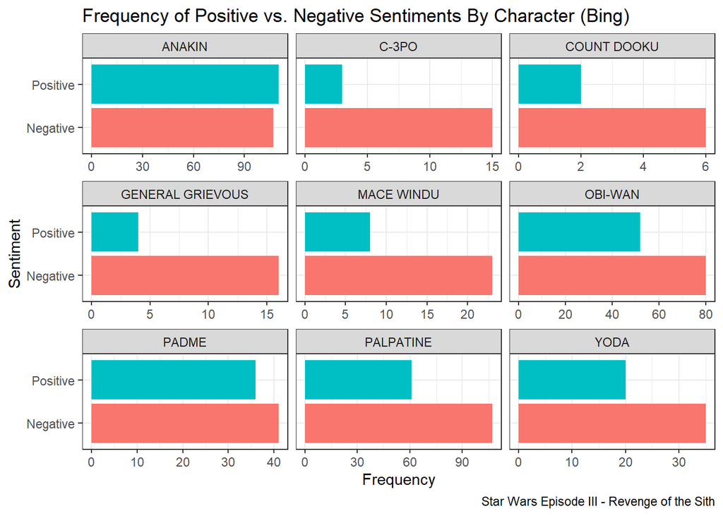

For those same 9 characters, we can observe the words they have used the most. In the following graph, we see that Obi-Wan and Padme each say `anakin` the most while Anakin says `master` the most. Palpatine also says `anakin` quite frequently, but not as much as the word `jedi`.

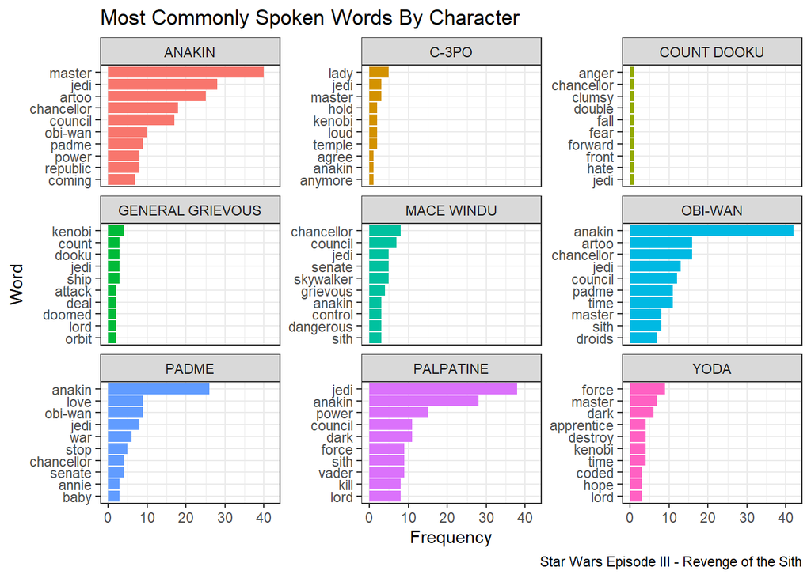

Along with word frequency, we also identified the words that were relevant to each character. In other words, we identified the words that were spoken almost uniquely by that character. In the following graph, we can see that words like `vader` were commonly used by Palpatine. For Mace Windu, the top word was the sound of Mace Windu grunting as he held off Palpatine’s force lightning attack with his lightsaber.

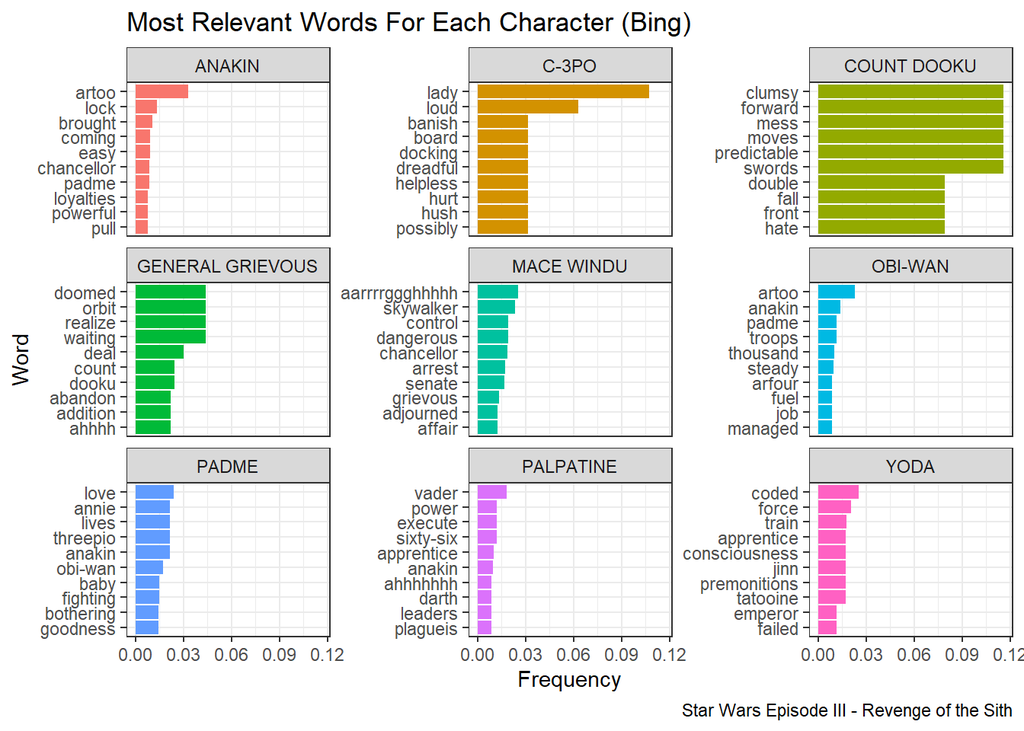

# Sentiment Analysis - NRC

We decided to try the NRC sentiments as they provided a wider range of sentiments.

The following table shows the total number of words for each sentiment.

| Sentiment | Total |
| --- | --- |
| Positive | 705 |
| Negative | 591 |
| Trust | 557 |
| Fear | 362 |
| Anticipation | 342 |
| Anger | 272 |
| Sadness | 264 |
| Joy | 217 |
| Disgust | 177 |
| Surprise | 129 |

The following is a visualization of the table directly above.

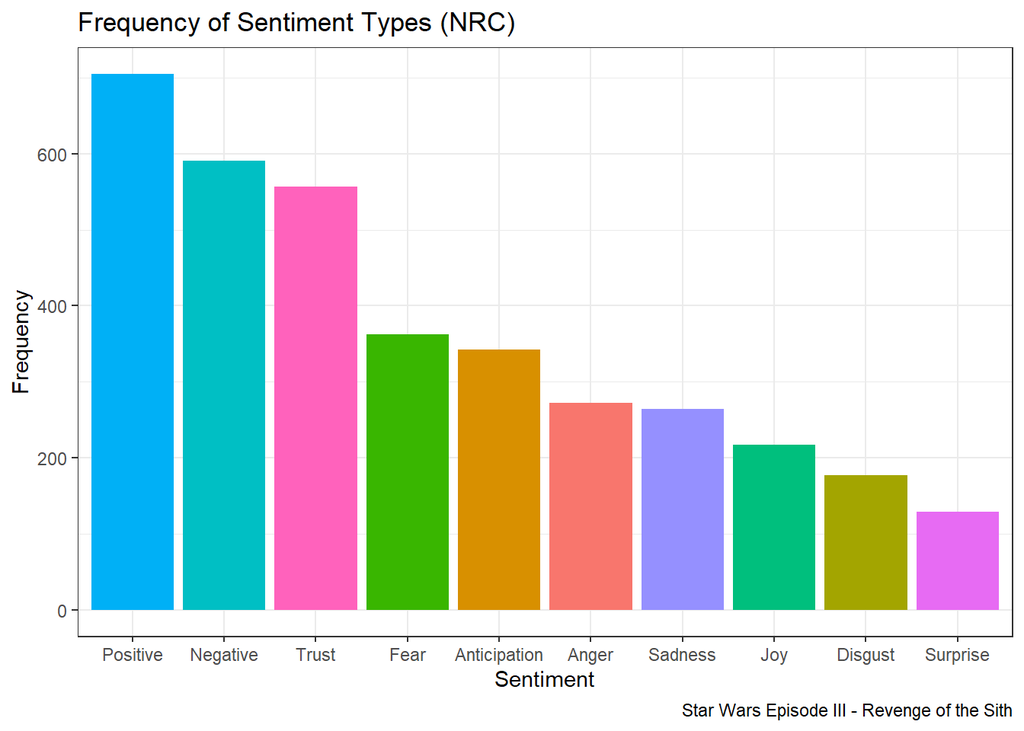

Similar to the previous analysis, we evaluated the frequency of each sentiment for each character. The spread is defined by the following formula:

$$Spread = N_{Anticipation} + N_{Joy} + N_{Positive} + N_{Surprise} + N_{Trust} - (N_{Anger} + N_{Disgust} + N_{Fear} + N_{Negative} + N_{Sadness})$$

Where each N represents the total number of words with that sentiment.

The following table shows the spreads for each character. Surprisingly, Obi-Wan was the 2nd-most positive instead of the 2nd-most negative. Also, Anakin was the most positive and Ki-Adi-Mundi was the most negative when using the NRC sentiments.

| Character | Anger | Anticipation | Disgust | Fear | Joy | Negative | Positive | Sadness | Surprise | Trust | NA | Spread |
| --- | --- | --- | --- | --- | --- | --- | --- | --- | --- | --- | --- | --- |
| ANAKIN | 68 | 91 | 53 | 83 | 60 | 139 | 191 | 69 | 29 | 138 | 432 | 97 |
| OBI-WAN | 40 | 73 | 16 | 58 | 26 | 95 | 115 | 39 | 23 | 88 | 488 | 77 |
| PADME | 18 | 24 | 8 | 28 | 34 | 49 | 59 | 23 | 11 | 51 | 174 | 53 |
| BAIL ORGANA | 7 | 7 | 4 | 12 | 8 | 13 | 23 | 3 | 4 | 18 | 87 | 21 |
| NUTE GUNRAY | 0 | 4 | 3 | 2 | 3 | 5 | 9 | 0 | 0 | 8 | 9 | 14 |
| PILOT | 0 | 2 | 0 | 2 | 1 | 1 | 5 | 1 | 1 | 4 | 15 | 9 |
| CLONE COMMANDER THIRE | 0 | 0 | 0 | 0 | 0 | 0 | 3 | 0 | 0 | 3 | 2 | 6 |
| GENERAL GRIEVOUS | 5 | 14 | 7 | 11 | 6 | 18 | 17 | 7 | 5 | 12 | 56 | 6 |
| MACE WINDU | 15 | 18 | 8 | 19 | 7 | 31 | 28 | 12 | 4 | 34 | 94 | 6 |
| MAS AMEDDA | 0 | 1 | 1 | 0 | 1 | 1 | 4 | 0 | 0 | 2 | 5 | 6 |
| MON MOTHMA | 0 | 1 | 0 | 1 | 1 | 5 | 3 | 1 | 1 | 6 | 23 | 5 |
| SUPER BATTLE DROID G21 | 0 | 0 | 0 | 0 | 0 | 0 | 3 | 0 | 0 | 2 | 3 | 5 |
| AAYLA | 0 | 0 | 0 | 0 | 0 | 0 | 0 | 0 | 2 | 2 | 2 | 4 |
| CLONE CAPTAIN | 0 | 2 | 0 | 0 | 0 | 0 | 1 | 0 | 0 | 1 | 2 | 4 |
| BODYGUARD | 0 | 0 | 0 | 0 | 1 | 0 | 1 | 0 | 0 | 1 | 3 | 3 |
| CHI EEKWAY | 0 | 1 | 0 | 0 | 0 | 0 | 1 | 0 | 0 | 1 | 1 | 3 |
| CLONE COMMANDER GREE | 0 | 0 | 2 | 0 | 0 | 2 | 4 | 0 | 0 | 3 | 4 | 3 |
| GUARD | 0 | 0 | 0 | 0 | 0 | 0 | 1 | 0 | 0 | 2 | 4 | 3 |
| JAR JAR | 0 | 0 | 0 | 0 | 0 | 0 | 1 | 0 | 0 | 2 | 7 | 3 |
| PALPATINE | 63 | 65 | 43 | 82 | 42 | 127 | 132 | 66 | 27 | 118 | 427 | 3 |
| CAPTAIN | 0 | 0 | 0 | 0 | 0 | 0 | 2 | 0 | 0 | 0 | 3 | 2 |
| CLONE COMMANDER BACARA | 0 | 0 | 1 | 0 | 0 | 1 | 2 | 0 | 0 | 2 | 0 | 2 |
| CLONE PILOT 2 | 0 | 0 | 0 | 0 | 0 | 0 | 0 | 0 | 2 | 0 | 3 | 2 |
| CLONE TROOPER | 0 | 0 | 0 | 0 | 0 | 1 | 2 | 1 | 0 | 2 | 1 | 2 |
| FANG ZAR | 0 | 1 | 0 | 0 | 0 | 0 | 0 | 0 | 0 | 1 | 4 | 2 |
| CLONE SERGEANT | 1 | 2 | 1 | 2 | 0 | 2 | 3 | 2 | 1 | 3 | 8 | 1 |
| CREATURE | 0 | 0 | 0 | 0 | 0 | 0 | 1 | 0 | 0 | 0 | 4 | 1 |
| PLO KOON | 0 | 0 | 0 | 0 | 0 | 0 | 1 | 0 | 0 | 0 | 2 | 1 |
| YOUNGLINGS | 0 | 0 | 0 | 0 | 0 | 0 | 1 | 0 | 0 | 0 | 1 | 1 |
| BATTLE DROID | 0 | 0 | 0 | 0 | 0 | 0 | 0 | 0 | 0 | 0 | 4 | 0 |
| BODYGUARD I | 0 | 0 | 0 | 0 | 0 | 0 | 0 | 0 | 0 | 0 | 4 | 0 |
| CAPTAIN ANTILLES | 1 | 0 | 0 | 0 | 0 | 1 | 1 | 0 | 0 | 1 | 7 | 0 |
| CAPTAIN TYPHO | 1 | 0 | 0 | 0 | 0 | 1 | 2 | 0 | 0 | 0 | 3 | 0 |
| CLONE PILOT 1 | 0 | 0 | 1 | 0 | 0 | 1 | 1 | 0 | 0 | 1 | 0 | 0 |
| DROID 1 | 0 | 0 | 0 | 0 | 0 | 0 | 0 | 0 | 0 | 0 | 3 | 0 |
| DROID 2 | 0 | 0 | 0 | 0 | 0 | 0 | 0 | 0 | 0 | 0 | 2 | 0 |
| MEDICAL DROID | 1 | 0 | 2 | 0 | 1 | 4 | 5 | 2 | 0 | 3 | 12 | 0 |
| MOTEE | 0 | 0 | 0 | 0 | 0 | 0 | 0 | 0 | 0 | 0 | 1 | 0 |
| ODD BALL | 1 | 0 | 0 | 1 | 0 | 2 | 2 | 0 | 0 | 2 | 7 | 0 |
| ROYAL GUARD | 0 | 0 | 0 | 0 | 0 | 0 | 0 | 0 | 0 | 0 | 1 | 0 |
| RUNE HAAKO | 0 | 0 | 0 | 0 | 0 | 0 | 0 | 0 | 0 | 0 | 1 | 0 |
| TERR TANEEL | 0 | 0 | 0 | 0 | 0 | 0 | 0 | 0 | 0 | 0 | 1 | 0 |
| WRANGLER | 0 | 0 | 0 | 0 | 0 | 0 | 0 | 0 | 0 | 0 | 4 | 0 |
| QUI-GON | 6 | 4 | 2 | 6 | 2 | 6 | 10 | 1 | 1 | 3 | 9 | -1 |
| SUPER BATTLE DROID 1 | 0 | 0 | 0 | 0 | 0 | 1 | 0 | 0 | 0 | 0 | 3 | -1 |
| SUPER BATTLE DROID 2 | 0 | 0 | 0 | 0 | 0 | 1 | 0 | 0 | 0 | 0 | 3 | -1 |
| TION MEDON | 2 | 1 | 0 | 2 | 1 | 3 | 2 | 0 | 0 | 2 | 11 | -1 |
| YODA | 22 | 22 | 11 | 28 | 15 | 41 | 44 | 17 | 10 | 27 | 148 | -1 |
| BANA BREEMU | 0 | 0 | 0 | 2 | 0 | 1 | 0 | 0 | 0 | 1 | 2 | -2 |
| CLONE COMMANDER APPO | 1 | 0 | 0 | 1 | 0 | 1 | 0 | 0 | 0 | 0 | 0 | -3 |
| CLONE COMMANDER CODY | 3 | 0 | 1 | 2 | 0 | 5 | 5 | 2 | 2 | 3 | 9 | -3 |
| GIDDEAN DANU | 1 | 1 | 1 | 2 | 0 | 3 | 0 | 0 | 1 | 2 | 13 | -3 |
| SUPER BATTLE DROID R77 | 2 | 1 | 2 | 2 | 1 | 2 | 1 | 2 | 1 | 1 | 0 | -5 |
| C-3PO | 5 | 7 | 4 | 9 | 5 | 13 | 13 | 10 | 3 | 4 | 43 | -9 |
| COUNT DOOKU | 3 | 0 | 3 | 2 | 1 | 6 | 4 | 2 | 0 | 1 | 8 | -10 |
| KI-ADI-MUNDI | 6 | 0 | 3 | 5 | 1 | 9 | 2 | 4 | 1 | 2 | 17 | -21 |

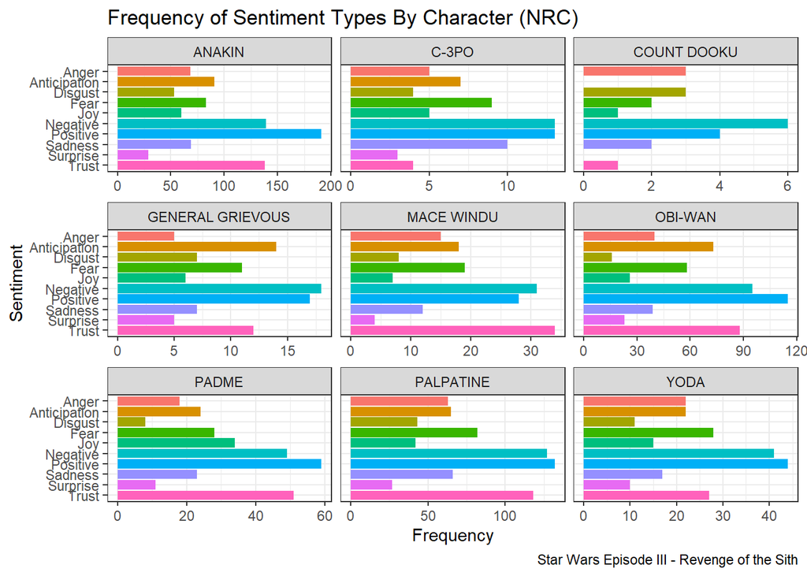

The following graph shows the 10 most common words by sentiment.

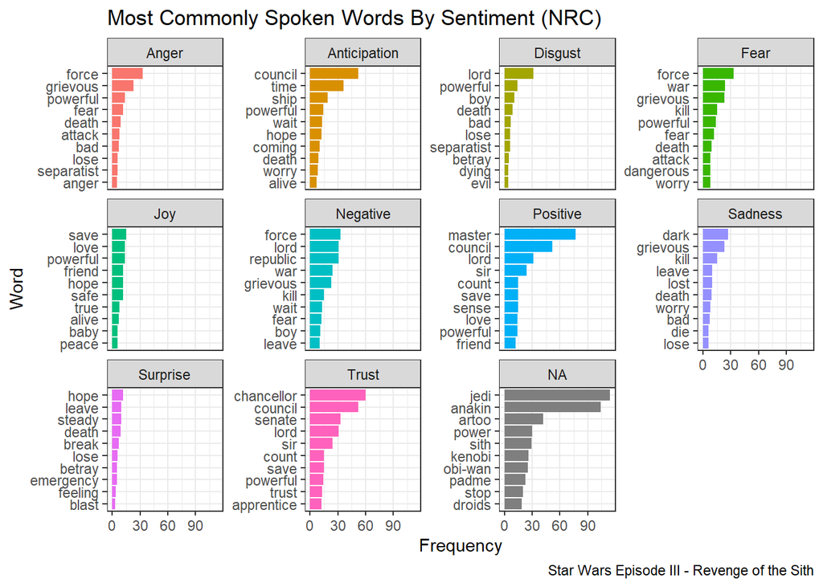

Using the NRC sentiments, we identified the most relevant words for each character. In the following graph, we see that Count Dooku and C-3PO frequently said `hate` and `weight` respectively.

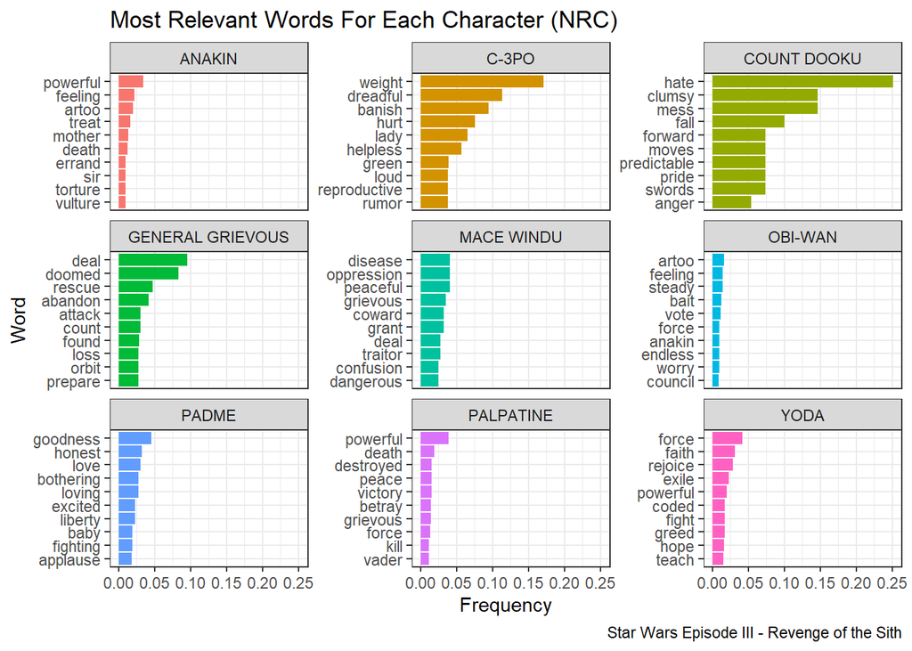

# Conclusion

The analysis revealed that the most common word was `jedi`. The most common positive word was overwhelmingly `master` and the most common negative word was `dark`. Despite Anakin’s conversion to the dark side, Anakin was among the most positive characters in the movie according to the Bing and NRC sentiments. Ki-Adi-Mundi was among the most negative, which was a surprise when considering he was a Jedi.

The NRC sentiments produced contrasting results, where the majority of the characters’ spreads were positive. Using the NRC sentiments also revealed that `chancellor` was the most common word with the `Trust` sentiment.